# Chip seq analysis

Angelo Limeta

September 13, 2024

## Load Libraries

```r
library(AnnotationDbi)
library(org.Hs.eg.db)
library(biomaRt)

library(tidyverse)
```

```r
library(ggrepel)
library(tidyHeatmap)
library(GenomicRanges)
library(ChIPseeker)
library(TxDb.Hsapiens.UCSC.hg38.knownGene)
select = dplyr::select
```

## Load data

```r
tbl_meta <- readRDS(file = "../../results/processed_data/tbl_meta.rds")
tbl_chip <- readRDS(file = "../../results/processed_data/tbl_chip.rds")

head(tbl_chip)
```

| sample_id | chrom | chromStart | chromEnd | name | score | strand | signalValue | pValue | qValue | peak |
| --- | --- | --- | --- | --- | --- | --- | --- | --- | --- | --- |
| S45085 | chr1 | 28665 | 29997 | macs2_output_S45085_IDC_352_peak_1 | 2038 | . | 48.17380 | 207.25900 | 203.85100 | 477 |
| S45085 | chr1 | 199057 | 200396 | macs2_output_S45085_IDC_352_peak_2 | 2755 | . | 60.42500 | 279.27400 | 275.51900 | 638 |
| S45085 | chr1 | 498538 | 498791 | macs2_output_S45085_IDC_352_peak_3 | 48 | . | 4.76114 | 6.74802 | 4.83337 | 84 |
| S45085 | chr1 | 605028 | 605639 | macs2_output_S45085_IDC_352_peak_4 | 162 | . | 8.61342 | 18.49880 | 16.29040 | 450 |
| S45085 | chr1 | 730481 | 730953 | macs2_output_S45085_IDC_352_peak_5 | 39 | . | 4.01337 | 5.86499 | 3.98749 | 279 |
| S45085 | chr1 | 736776 | 737098 | macs2_output_S45085_IDC_352_peak_6 | 39 | . | 3.99208 | 5.82980 | 3.96257 | 141 |

```r
head(tbl_meta)
```

| sample_id | method | condition |
| --- | --- | --- |
| S57532 | chip_seq | scr |
| S57533 | chip_seq | kd |
| S45085 | chip_seq | scr |
| S45086 | chip_seq | kd |
| S45028 | rna_seq | scr |
| S45030 | rna_seq | kd |

## Check the event distribution

Let’s plot peaks across chromosomes and samples.

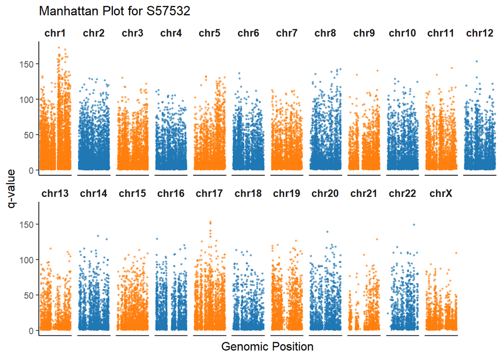

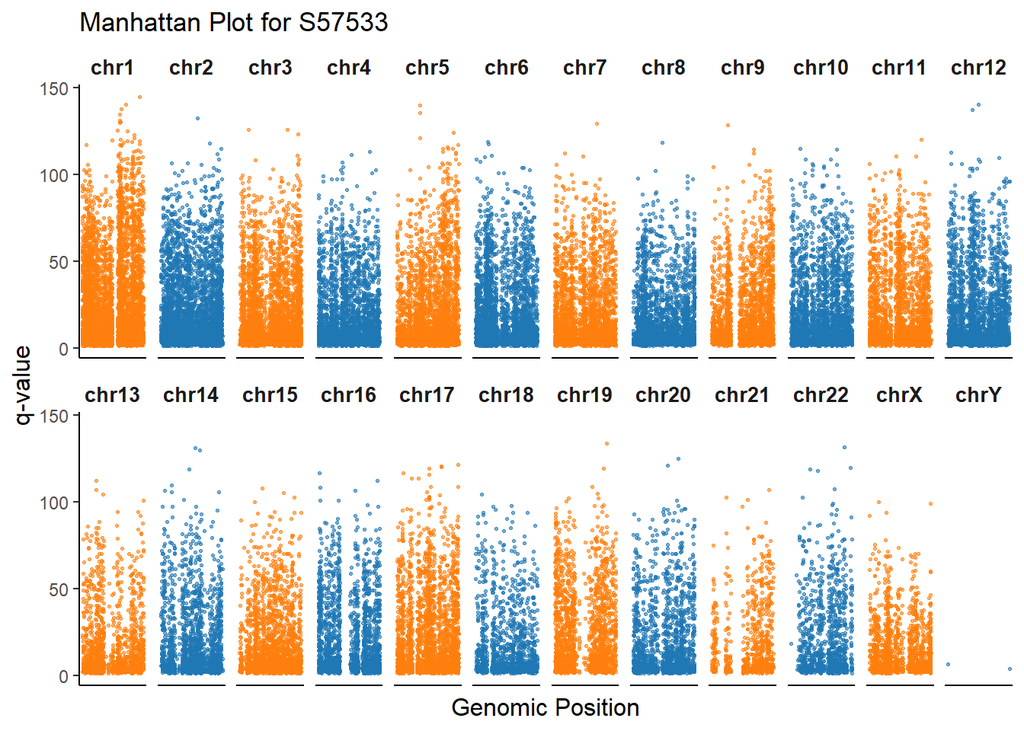

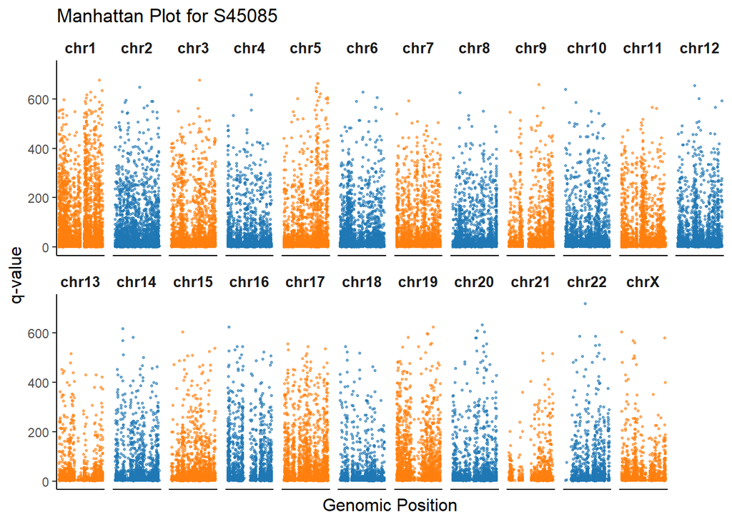

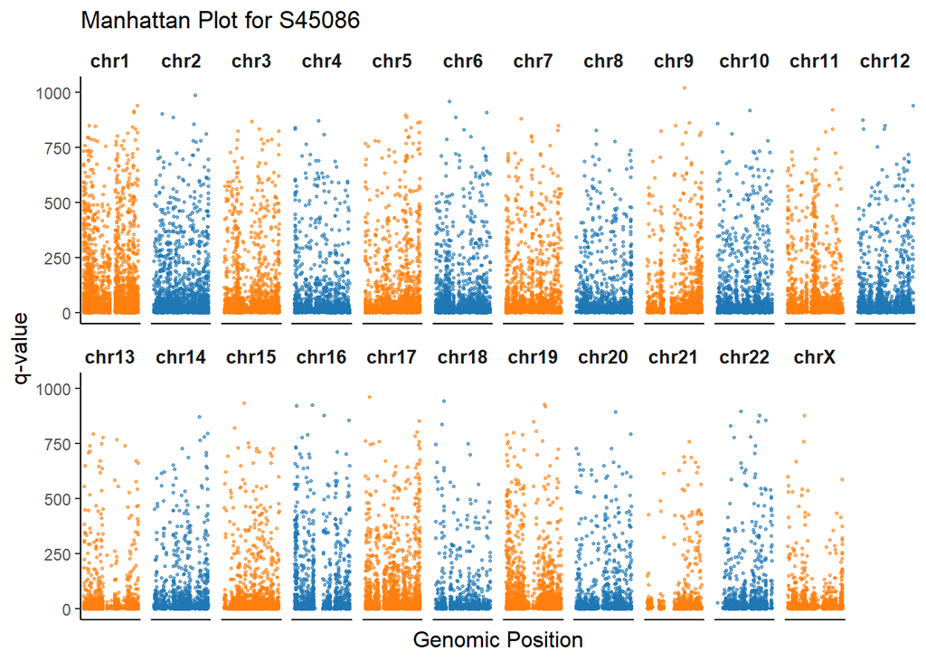

```r
# Specify chip samples
chip_samples <- tbl_meta %>% filter(method == "chip_seq") %>% pull(sample_id)

# Ensure chromosomes are ordered correctly (numerically and X/Y at the end)
tbl_chip_ordered <- tbl_chip %>%
  mutate(
    chrom = factor(chrom, levels = c(paste0("chr", 1:22), "chrX", "chrY"))
  ) %>%
  filter(!is.na(chrom))  # Remove non-standard chromosomes

# Define a two-color palette to alternate between chromosomes
two_color_palette <- c("#1f77b4", "#ff7f0e")  # Blue and orange

# Assign alternating colors to chromosomes
tbl_chip_ordered <- tbl_chip_ordered %>%
  mutate(chrom_color = as.factor(as.numeric(chrom) %% 2 + 1))  # Alternate colors

# Plot the Manhattan plots
for (id in chip_samples) {
  plot <- tbl_chip_ordered %>%
    filter(sample_id == id) %>%
    ggplot(aes(x = chromStart, y = qValue, color = chrom_color)) +
    geom_point(alpha = 0.6, size = 0.6) +

    facet_wrap(~ chrom, scales = "free_x", nrow = 2) +

    # Add labels and titles
    labs(
      title = paste0("Manhattan Plot for ", id),
      x = "Genomic Position",
      y = "q-value"
    ) +
    theme_classic() +
    theme(
      legend.position = "none",  # Remove legend for simplicity
      strip.background = element_blank(),  # Remove background from facet labels
      strip.text = element_text(size = 10, face = "bold"),  # Bold facet labels
      axis.title = element_text(size = 12),  # Increase axis title size
      axis.text.x = element_blank(),  # Hide x-axis text
      axis.ticks.x = element_blank()  # Hide x-axis ticks
    ) +
    # Use the two-color palette for chromosomes
    scale_color_manual(values = two_color_palette)

  print(plot)
  ggsave(plot = plot, filename = paste0("../../results/figures/chip_chrom_peaks_",id,".pdf"))
}
```

## Differential peak analysis

We begin by loading the macs2 outputs, and then let’s merge overlapping peaks

```r
# Define file paths for the narrowPeak files
chip_seq_files <- list.files(path = "../../results/chip_data/macs2/", pattern = "*.narrowPeak", full.names = TRUE)

# Load and combine peaks
load_chip_data <- function(file) {
  sample_id <- str_replace(basename(file), "_peaks.narrowPeak", "")
  sample_id <- gsub(".*macs2_output_","",sample_id)
  sample_id <- gsub("_ID.*","",sample_id)
  read_tsv(file, col_names = FALSE) %>%
    mutate(sample_id = sample_id) %>%
    rename(
      chrom = X1,
      chromStart = X2,
      chromEnd = X3,
      name = X4,
      score = X5,
      strand = X6,
      signalValue = X7,
      pValue = X8,
      qValue = X9,
      peak = X10
    )
}

# Combine all narrowPeak files into a single tibble
tbl_chip <- bind_rows(lapply(chip_seq_files, load_chip_data))
```

```r
# Create a list of GRanges objects, one for each sample
granges_list <- tbl_chip %>%
  split(.$sample_id) %>%
  map(~GRanges(
    seqnames = .$chrom,
    ranges = IRanges(start = .$chromStart, end = .$chromEnd),
    signalValue = .$signalValue  # Assuming this is the score you'd like to retain
  ))

# Combine all GRanges objects into a single GRangesList
granges_combined <- GRangesList(granges_list)

# Flatten the GRangesList into a single GRanges object
granges_flat <- unlist(granges_combined)

# Now reduce the flattened GRanges object to merge overlapping peaks
merged_peaks <- reduce(granges_flat)
```

Now we will create a signal matrix, i.e. rows corresponding to merged peaks and columns for samples

```r
# Initialize an empty matrix to store signal values (one row per merged peak, one column per sample)
score_matrix <- matrix(NA, nrow = length(merged_peaks), ncol = length(granges_list))
colnames(score_matrix) <- names(granges_list)  # Set sample names as column names

# Fill the matrix with signal values based on overlaps
for (i in seq_along(granges_list)) {
  sample_gr <- granges_list[[i]]
  overlaps <- findOverlaps(merged_peaks, sample_gr)

  # Fill in the signal values for the peaks that overlap
  score_matrix[queryHits(overlaps), i] <- sample_gr$signalValue[subjectHits(overlaps)]
}

# Convert the matrix to a data frame for easier manipulation later
score_df <- as.data.frame(score_matrix)
colnames(score_df) <- names(granges_list)

# Add peak information (chromosome, start, end) to the score matrix
merged_peaks_df <- as.data.frame(merged_peaks)
score_df <- cbind(merged_peaks_df, score_df)

# Preview the final score data frame
head(score_df)
```

|  | seqnames | start | end | width | strand | S45085 | S45086 | S57532 | S57533 |
| --- | --- | --- | --- | --- | --- | --- | --- | --- | --- |
| 1 | chr1 | 28120 | 29997 | 1878 | * | 48.17380 | 95.32710 | 26.85490 | 21.61330 |
| 2 | chr1 | 198638 | 200445 | 1808 | * | 60.42500 | 104.94600 | 28.89970 | 25.87140 |
| 3 | chr1 | 495733 | 496056 | 324 | * | NA | 6.70930 | NA | NA |
| 4 | chr1 | 498538 | 498791 | 254 | * | 4.76114 | NA | NA | NA |
| 5 | chr1 | 604957 | 605645 | 689 | * | 8.61342 | 5.75731 | 4.80323 | 5.47584 |
| 6 | chr1 | 730298 | 730977 | 680 | * | 4.01337 | 6.57978 | NA | NA |

```r
# Add condition information to the score matrix (from tbl_meta)
sample_conditions <- tbl_meta %>%
  filter(sample_id %in% colnames(score_matrix)) %>%
  arrange(match(sample_id, colnames(score_matrix))) %>%
  pull(condition)

# Initialize vectors to store p-values and logFC
p_values <- rep(NA, nrow(score_matrix))
log_fc <- rep(NA, nrow(score_matrix))  # Initialize for logFC

# Loop through each row (peak) in the score matrix
for (i in 1:nrow(score_matrix)) {
  # Get the signal values for the current peak
  row <- score_matrix[i, ]

  # Separate the values by condition (scr vs kd)
  scr_values <- row[sample_conditions == "scr"]
  kd_values <- row[sample_conditions == "kd"]

  # Check if there are enough non-NA values in both conditions
  if (sum(!is.na(scr_values)) > 1 && sum(!is.na(kd_values)) > 1) {
    # Perform the t-test and store the p-value
    p_values[i] <- t.test(scr_values, kd_values)$p.value

    # Calculate log2 fold change (logFC) if both conditions have non-zero means
    if (mean(scr_values, na.rm = TRUE) > 0 && mean(kd_values, na.rm = TRUE) > 0) {
      log_fc[i] <- log2(mean(kd_values, na.rm = TRUE) / mean(scr_values, na.rm = TRUE))
    } else {
      log_fc[i] <- NA  # Avoid log transformation issues with zero means
    }
  } else {
    p_values[i] <- NA  # Store NA if not enough data points
    log_fc[i] <- NA  # Also store NA for logFC in these cases
  }
}

# Adjust p-values for multiple testing using the Benjamini-Hochberg method (FDR)
adjusted_p_values <- p.adjust(p_values, method = "BH")

# Add p-values, adjusted p-values, and logFC to the score_df
score_df$p_value <- p_values
score_df$adj_p_value <- adjusted_p_values
score_df$logFC <- log_fc

# Sort by p-value to find the most significant differential peaks
score_df <- score_df %>%
  arrange(p_value) %>%
  filter(!is.na(p_value))

# Preview the top differentially enriched peaks with logFC
head(score_df)
```

|  | seqnames | start | end | width | strand | S45085 | S45086 | S57532 | S57533 | p_value | adj_p_value | logFC |
| --- | --- | --- | --- | --- | --- | --- | --- | --- | --- | --- | --- | --- |
| 1 | chr4 | 87077898 | 87079867 | 1970 | * | 5.99469 | 7.08420 | 6.01610 | 7.07003 | 0.0003943267 | 0.9998868 | 0.2369022 |
| 2 | chr17 | 44152328 | 44153772 | 1445 | * | 9.03314 | 6.03646 | 9.12999 | 5.95515 | 0.0005068043 | 0.9998868 | -0.5989875 |
| 3 | chr17 | 15981480 | 15982993 | 1514 | * | 7.38674 | 5.80118 | 7.43761 | 5.74275 | 0.0006253725 | 0.9998868 | -0.3608344 |
| 4 | chr11 | 76791830 | 76792915 | 1086 | * | 7.38674 | 5.34607 | 7.48109 | 5.43668 | 0.0010332097 | 0.9998868 | -0.4634689 |
| 5 | chr7 | 80829035 | 80831524 | 2490 | * | 8.92009 | 3.10608 | 8.70026 | 3.26201 | 0.0010582403 | 0.9998868 | -1.4683100 |
| 6 | chr6 | 109055096 | 109057022 | 1927 | * | 4.39004 | 10.69210 | 4.15720 | 10.82890 | 0.0015248244 | 0.9998868 | 1.3322146 |

Let’s annotate the peaks so we know which genes are connected to it.

We will use ChipSeeker for this.

```r
# Convert the merged peaks back to a GRanges object from score_df
granges_peaks <- GRanges(
  seqnames = score_df$seqnames,
  ranges = IRanges(start = score_df$start, end = score_df$end)
)

# Annotate peaks with ChIPseeker
peak_annotation <- annotatePeak(
  granges_peaks,
  TxDb = TxDb.Hsapiens.UCSC.hg38.knownGene,
  annoDb = "org.Hs.eg.db"
)
```

```
## >> preparing features information...      2024-09-13 16:05:24
## >> identifying nearest features...        2024-09-13 16:05:26
## >> calculating distance from peak to TSS...   2024-09-13 16:05:28
## >> assigning genomic annotation...        2024-09-13 16:05:28
## >> adding gene annotation...          2024-09-13 16:06:26
```

```
## >> assigning chromosome lengths           2024-09-13 16:06:26
## >> done...                    2024-09-13 16:06:26
```

```r
# Convert the annotated peaks to a data frame
annotated_df <- as.data.frame(peak_annotation)

# Merge the annotation with the score_df based on peak location
score_df_annotated <- score_df %>%
  mutate(peak_id = paste(seqnames, start, end, sep = "_")) %>%
  left_join(annotated_df %>%
              mutate(peak_id = paste(seqnames, start, end, sep = "_")),
            by = "peak_id") %>%
  select(-c( "seqnames.y","start.y","end.y","width.y","strand.y"))

# Preview the annotated peaks with gene symbols
head(score_df_annotated)
```

|  | seqnames.x | start.x | end.x | width.x | strand.x | S45085 | S45086 | S57532 | S57533 | p_value | adj_p_value | logFC | peak_id | annotation | geneChr | geneStart | geneEnd | geneLength | geneStrand | geneId | transcriptId | distanceToTSS | ENSEMBL | SYMBOL | GENENAME |
| --- | --- | --- | --- | --- | --- | --- | --- | --- | --- | --- | --- | --- | --- | --- | --- | --- | --- | --- | --- | --- | --- | --- | --- | --- | --- |
| 1 | chr4 | 87077898 | 87079867 | 1970 | * | 5.99469 | 7.08420 | 6.01610 | 7.07003 | 0.0003943267 | 0.9998868 | 0.2369022 | chr4_87077898_87079867 | Intron (ENST00000507468.5/4299, intron 4 of 6) | 4 | 87049652 | 87108312 | 58661 | 1 | 4299 | ENST00000514970.2 | 28246 | ENSG00000172493 | AFF1 | ALF transcription elongation factor 1 |
| 2 | chr17 | 44152328 | 44153772 | 1445 | * | 9.03314 | 6.03646 | 9.12999 | 5.95515 | 0.0005068043 | 0.9998868 | -0.5989875 | chr17_44152328_44153772 | Promoter (<=1kb) | 17 | 44154360 | 44162004 | 7645 | 1 | 78995 | ENST00000588073.1 | -588 | ENSG00000125319 | HROB | homologous recombination factor with OB-fold |
| 3 | chr17 | 15981480 | 15982993 | 1514 | * | 7.38674 | 5.80118 | 7.43761 | 5.74275 | 0.0006253725 | 0.9998868 | -0.3608344 | chr17_15981480_15982993 | Promoter (1-2kb) | 17 | 15976569 | 15980367 | 3799 | 2 | 125150 | ENST00000497434.6 | -1113 | ENSG00000214941 | ZSWIM7 | zinc finger SWIM-type containing 7 |
| 4 | chr11 | 76791830 | 76792915 | 1086 | * | 7.38674 | 5.34607 | 7.48109 | 5.43668 | 0.0010332097 | 0.9998868 | -0.4634689 | chr11_76791830_76792915 | Promoter (<=1kb) | 11 | 76791752 | 76798144 | 6393 | 1 | 25987 | ENST00000527881.1 | 78 | ENSG00000182704 | TSKU | tsukushi, small leucine rich proteoglycan |
| 5 | chr7 | 80829035 | 80831524 | 2490 | * | 8.92009 | 3.10608 | 8.70026 | 3.26201 | 0.0010582403 | 0.9998868 | -1.4683100 | chr7_80829035_80831524 | Intron (ENST00000265361.8/10512, intron 2 of 17) | 7 | 80815949 | 80818409 | 2461 | 2 | 10512 | ENST00000459652.1 | -10626 | ENSG00000075223 | SEMA3C | semaphorin 3C |
| 6 | chr6 | 109055096 | 109057022 | 1927 | * | 4.39004 | 10.69210 | 4.15720 | 10.82890 | 0.0015248244 | 0.9998868 | 1.3322146 | chr6_109055096_109057022 | Intron (ENST00000436639.7/27244, intron 1 of 9) | 6 | 109088102 | 109093968 | 5867 | 2 | 27244 | ENST00000517548.1 | 36946 | ENSG00000080546 | SESN1 | sestrin 1 |

Let’s plot the top differentially expressed peaks in a volcano plot

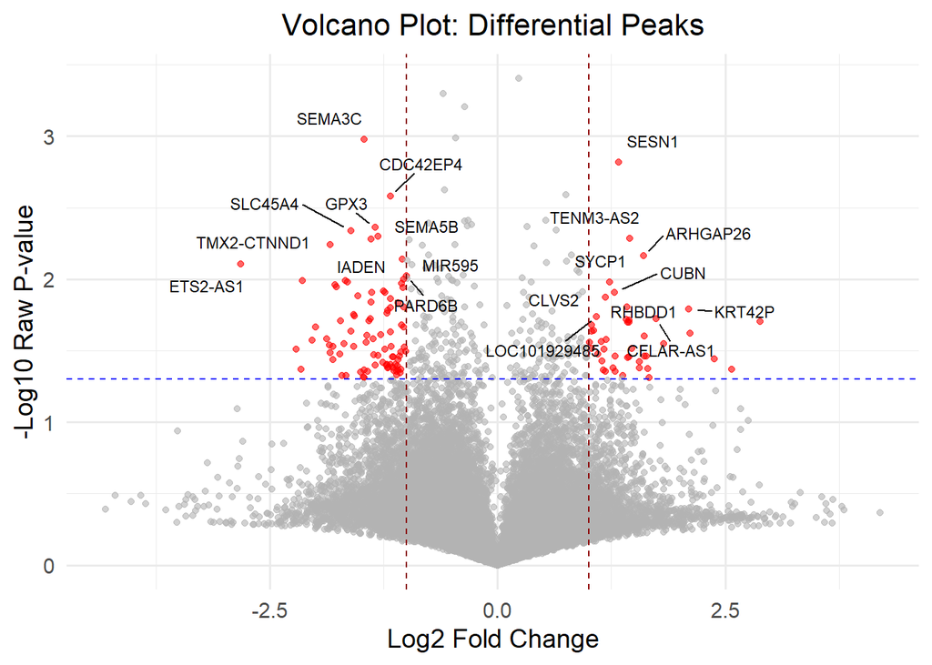

```r
# Define thresholds for significance (logFC and raw p-values)
logfc_threshold <- 1  # Log2 fold change threshold
pval_threshold <- 0.05  # Raw p-value threshold

# Select the top 10 upregulated and top 10 downregulated peaks based on raw p-values
top_upregulated <- score_df_annotated %>%
  filter(logFC > logfc_threshold, p_value < pval_threshold) %>%
  arrange(p_value) %>%
  slice(1:10)

top_downregulated <- score_df_annotated %>%
  filter(logFC < -logfc_threshold, p_value < pval_threshold) %>%
  arrange(p_value) %>%
  slice(1:10)

# Combine top upregulated and downregulated peaks for labeling
top_peaks <- bind_rows(top_upregulated, top_downregulated)

# Volcano plot using raw p-values
p_volcano <- score_df_annotated %>%
  ggplot(aes(x = logFC, y = -log10(p_value))) +

  # Add points colored by significance (raw p-values and logFC)
  geom_point(aes(color = p_value < pval_threshold & abs(logFC) > logfc_threshold),
             alpha = 0.6, size = 1.5) +

  # Highlight top 10 upregulated and downregulated peaks with gene names
  geom_text_repel(
    data = top_peaks,
    aes(label = SYMBOL),  # Use gene name for labeling
    size = 3,
    box.padding = 0.5,
    point.padding = 0.5,
    max.overlaps = Inf,
    segment.color = 'black',
    segment.size = 0.5
  ) +

  # Add vertical lines for logFC thresholds
  geom_vline(xintercept = c(-logfc_threshold, logfc_threshold),
             linetype = "dashed", color = "darkred") +

  # Add horizontal line for raw p-value threshold
  geom_hline(yintercept = -log10(pval_threshold),
             linetype = "dashed", color = "blue") +

  # Customize labels and theme
  labs(
    title = "Volcano Plot: Differential Peaks",
    x = "Log2 Fold Change",
    y = "-Log10 Raw P-value"
  ) +
  scale_color_manual(values = c("grey70", "red")) +
  theme_minimal(base_size = 14) +
  theme(legend.position = "none", plot.title = element_text(hjust = 0.5, size = 16))

# Display plot
p_volcano
```

```r
# Save the plot to a file
ggsave(filename = "../../results/figures/chip_volcano.pdf", plot = p_volcano, width = 8, height = 6)
```

Let’s also see where they are on the genome.

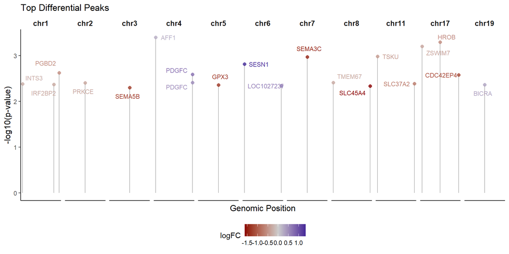

```r
# Remove ".x" from column names
colnames(score_df_annotated) <- gsub("\\.x$", "", colnames(score_df_annotated))

# Filter valid chromosomes from score_df_annotated
valid_chromosomes <- c(paste0("chr", 1:22), "chrX", "chrY")

# Ensure chromosomes are ordered correctly (numerically and X/Y at the end)
score_df_ordered <- score_df_annotated %>%
  filter(seqnames %in% valid_chromosomes) %>%
  mutate(
    seqnames = factor(seqnames, levels = c(paste0("chr", 1:22), "chrX", "chrY"))
  )

# Filter the top peaks for the Manhattan plot
top_peaks_manhattan <- score_df_ordered %>%
  filter(!is.na(logFC)) %>%
  arrange(adj_p_value) %>%
  slice_head(n = 20)  # Take top 20 peaks (10 upregulated, 10 downregulated)

# Create Manhattan plot with alternating colors for logFC
p_manhattan <- top_peaks_manhattan %>%
  ggplot(aes(x = start, y = -log10(p_value), color = logFC)) +

  # Lollipop line from x-axis to each point
  geom_segment(aes(x = start, xend = start, y = 0, yend = -log10(p_value)), color = "gray70") +

  # Points colored by logFC (dark red for negative, dark blue for positive)
  geom_point(alpha = 0.8, size = 2) +

  # Label significant peaks with gene names using geom_text_repel
  geom_text_repel(
    aes(label = SYMBOL),
    size = 3,
    box.padding = 0.5,
    point.padding = 0.5,
    max.overlaps = 10,
    segment.color = 'black',
    segment.size = 0.5
  ) +

  # Facet by chromosome, no free scales for x-axis
  facet_wrap(~ seqnames, scales = "free_x", nrow = 1) +

  # Customize color gradient for logFC
  scale_color_gradient2(
    low = "darkred", mid = "grey80", high = "darkblue", midpoint = 0
  ) +

  # Customize labels and theme
  labs(
    title = "Top Differential Peaks",
    x = "Genomic Position",
    y = "-log10(p-value)"
  ) +
  theme_classic() +
  theme(
    strip.background = element_blank(),
    strip.text = element_text(size = 10, face = "bold"),
    axis.title = element_text(size = 12),
    axis.text.x = element_blank(),
    axis.ticks.x = element_blank(),
    legend.position = "bottom"
  )

# Display the plot
print(p_manhattan)
```

```r
# Save plot to file
ggsave(filename = "../../results/figures/chip_chrom_top_differential_peaks.pdf", plot = p_manhattan, width = 10, height = 6)
```

Let’s just check genes that are annotated for the top peaks:

```r
top_peaks %>% select(SYMBOL,logFC,p_value,adj_p_value) %>% print()
```

```
##          SYMBOL     logFC     p_value adj_p_value
## 1         SESN1  1.332215 0.001524824   0.9998868
## 2     TENM3-AS2  1.448165 0.005210223   0.9998868
## 3      ARHGAP26  1.600913 0.006891857   0.9998868
## 4         SYCP1  1.234297 0.010489049   0.9998868
## 5          CUBN  1.285622 0.012415284   0.9998868
## 6         CLVS2  1.181739 0.013464396   0.9998868
## 7        RHBDD1  1.425068 0.015686460   0.9998868
## 8        KRT42P  2.096042 0.016180770   0.9998868
## 9  LOC101929485  1.088725 0.018237897   0.9998868
## 10    CFLAR-AS1  1.739146 0.018951320   0.9998868
## 11       SEMA3C -1.468310 0.001058240   0.9998868
## 12     CDC42EP4 -1.177351 0.002638192   0.9998868
## 13         GPX3 -1.342965 0.004360072   0.9998868
## 14      SLC45A4 -1.613370 0.004590600   0.9998868
## 15       SEMA5B -1.310238 0.005024236   0.9998868
## 16        IADEN -1.386197 0.005247697   0.9998868
## 17  TMX2-CTNND1 -1.841518 0.005711858   0.9998868
## 18       MIR595 -1.049999 0.007256729   0.9998868
## 19     ETS2-AS1 -2.818988 0.007802358   0.9998868
## 20       PARD6B -1.000501 0.009464562   0.9998868
```

Upregulated peaks:

1. **SESN1 (Sestrin 1)**:  
   Sestrin 1 is part of the sestrin family and is involved in the regulation of oxidative stress and mTOR signaling. It has been linked to tumor suppression in various cancers, including breast cancer. Upregulation of SESN1 could indicate a cellular response to stress or changes in metabolism induced by the knockdown of TACSTD2, which could affect survival pathways, especially in TNBC cells where oxidative stress is a key factor.
2. **TENM3-AS2 (Teneurin Transmembrane Protein 3, antisense RNA 2)**:  
   This is a non-coding RNA with unclear function.
3. **ARHGAP26 (Rho GTPase-activating protein 26)**:  
   ARHGAP26 is involved in cytoskeleton organization and cell motility, pathways that are often deregulated in cancers like TNBC, which are highly metastatic. This protein might play a role in the response to TACSTD2 knockdown by altering the cytoskeletal dynamics, which could affect migration or invasion.
4. **SYCP1 (Synaptonemal Complex Protein 1)**:  
   This is typically involved in meiosis, but in cancer, the expression of meiotic genes is often deregulated. Its upregulation might reflect abnormal gene expression as the cell line responds to knockdown, possibly impacting genomic stability or cell cycle control, which are key factors in TNBC progression.
5. **CUBN (Cubilin)**:  
   Cubilin is a receptor involved in endocytosis, including the uptake of proteins such as vitamin D-binding protein. It has been found to be overexpressed in some cancers and could be linked to nutrient uptake pathways. In TNBC cells, changes in CUBN expression might reflect shifts in metabolic processes triggered by TACSTD2 knockdown, which could impact cellular survival or growth.
6. **CLVS2 (Clavesin 2)**:  
   CLVS2 is associated with endosome trafficking, and dysregulation of intracellular trafficking can be important in cancer progression. The knockdown of TACSTD2, a cell surface glycoprotein, might affect similar pathways, explaining CLVS2 upregulation.
7. **RHBDD1 (Rhomboid domain-containing protein 1)**:  
   RHBDD1 is linked to apoptosis and may play a role in cell survival. Its upregulation in response to TACSTD2 knockdown might be connected to the regulation of apoptosis or stress response pathways, processes that are often altered in cancer cells to promote survival under adverse conditions.
8. **KRT42P (Keratin 42, pseudogene)**:  
   As a pseudogene, KRT42P itself might not be functional, but its transcriptional activation could indicate broader deregulation of keratin genes. TACSTD2 knockdown might affect keratin-related pathways, particularly in epithelial cells such as breast cancer cells.
9. **LOC101929485**:  
   This is an uncharacterized locus.
10. **CFLAR-AS1 (CFLAR Antisense RNA 1)**:  
    CFLAR is involved in the regulation of apoptosis and NF-κB signaling, pathways critical for cancer cell survival. TACSTD2 knockdown might affect these pathways, especially in highly aggressive and apoptosis-resistant TNBC cells.

Many of these genes seem to be involved in pathways related to apoptosis, cell motility, metabolism, and oxidative stress, which are highly relevant in cancers. Given **TACSTD2**’s role in promoting tumor growth and metastasis, these changes might reflect downstream effects of its knockdown, altering cell survival and metastatic potential in TNBC cells.

Downregulated peaks:

1. **SEMA3C (Semaphorin 3C)**:  
   Semaphorin 3C plays a role in cell migration, invasion, and angiogenesis, processes that are often heightened in TNBC. SEMA3C downregulation could suggest a reduction in invasive behavior or altered cell signaling in response to TACSTD2 knockdown.
2. **CDC42EP4 (CDC42 Effector Protein 4)**:  
   CDC42EP4 regulates actin cytoskeleton reorganization, affecting cell shape and movement. Its downregulation may reflect reduced cell motility, which is critical for cancer metastasis, possibly attenuating the aggressive phenotype typical of TNBC.
3. **GPX3 (Glutathione Peroxidase 3)**:  
   GPX3 is an antioxidant enzyme that protects cells from oxidative stress. Downregulation could indicate that cells are experiencing increased oxidative stress, which is common in cancer cells, especially when pathways related to cell survival or stress response (like those influenced by TACSTD2) are altered.
4. **SLC45A4 (Solute Carrier Family 45 Member 4)**:  
   SLC45A4 is involved in transport processes across cell membranes. While its direct role in cancer is less clear, reduced expression may affect nutrient transport or cellular metabolism, which could influence cancer cell survival in nutrient-deprived environments like those typical of aggressive breast cancers.
5. **SEMA5B (Semaphorin 5B)**:  
   Another member of the semaphorin family, SEMA5B is implicated in cell guidance and signaling. Its downregulation might further disrupt pathways related to cell migration and invasion, potentially reducing metastatic behavior in TACSTD2 knockdown cells.
6. **IADEN (Intercellular Adhesion Endothelial Cell Protein)**:  
   IADEN is less well-characterized, but its name suggests a role in cell adhesion. A reduction in adhesion proteins can impact how cancer cells interact with their microenvironment, which may alter their ability to invade and metastasize.
7. **TMX2-CTNND1 (TMX2-CTNND1 Fusion)**:  
   TMX2 is involved in oxidative stress, and CTNND1 (Catenin Delta-1) regulates cell-cell adhesion and signaling. This fusion gene’s downregulation might disrupt these pathways, potentially affecting cancer cell adhesion and response to oxidative stress in TACSTD2 knockdown cells.
8. **MIR595 (MicroRNA 595)**:  
   MicroRNA.
9. **ETS2-AS1 (ETS2 Antisense RNA 1)**:  
   This antisense RNA regulates the expression of ETS2, a gene involved in cell cycle regulation and apoptosis.
10. **PARD6B (Partitioning Defective 6 Homolog Beta)**:  
    PARD6B is involved in cell polarity and tight junction formation. In cancer, loss of cell polarity contributes to metastasis. Its downregulation might reflect altered cell polarity and junction integrity, which could affect the migration and invasive potential of the TNBC cells.

Several downregulated genes are involved in key processes such as **cell motility, adhesion, oxidative stress response, and cell cycle regulation**. This fits with the hypothesis that **TACSTD2** knockdown might reduce the aggressiveness and metastatic potential of the TNBC

## Enhancers

Finally, let’s check out the top peaks labeled as distal intergenic, which could correspond to enhancers.

```r
top_ten_enhancers <-
  score_df_ordered %>%
  filter(annotation == "Distal Intergenic") %>%
  slice_head(n = 10)

# Save to file
saveRDS(top_ten_enhancers, file = "../../results/processed_data/top_enhancers.rds")

top_ten_enhancers %>%
  select(SYMBOL, p_value, logFC)
```

| SYMBOL | p_value | logFC |
| --- | --- | --- |
| IRF2BP2 | 0.004238136 | -0.3309465 |
| BICRA | 0.004312814 | 0.3233663 |
| IADEN | 0.005247697 | -1.3861972 |
| LOC105379121 | 0.005786897 | -0.8255526 |
| RAPH1 | 0.007949999 | -0.9386843 |
| LOC105371672 | 0.008010170 | -0.6897153 |
| LOC124904666 | 0.008372844 | -0.6197216 |
| PARD6B | 0.009464562 | -1.0005005 |
| HS3ST1 | 0.009568839 | -0.5358435 |
| GCNT1 | 0.010534308 | -1.6442615 |

## Issues

This analysis has limitations, primarily due to the low sample size (only two samples per condition), which reduces statistical power and leads to high p-values and unreliable results. Additionally, the t-test approach may not fully capture the complexity of ChIP-seq data, as it doesn’t account for variability in peak shapes and enrichment across replicates. Ideally, a dedicated tool like DiffBind should be used for differential peak analysis, as it is specifically designed to handle the unique characteristics of ChIP-seq data, incorporating biological replicates and providing more accurate statistical assessments of differential binding.